# State MSM Profile: **Oregon**

### Background & Methods

In 2015-2016, researchers at Emory University partnered with colleagues at the Centers for Disease Control and Prevention (CDC) to develop methods to estimate the number of men who have sex with men (MSM) residing in each county in the United States. Using population and housing data from the [American Community Survey](https://www.census.gov/programs-surveys/acs/) and estimates from two peer-reviewed publications ([Oster et al., 2015](http://www.ncbi.nlm.nih.gov/pubmed/26115985) & [Purcell et al., 2012](http://www.ncbi.nlm.nih.gov/pubmed/23049658)), they derived an indirect estimate of MSM population sizes that took into account both the urbanicity of the county as well as its density of households with a male householder and a male same-sex partner.

The full methodology is published in the *Journal of Medical Internet Research - Public Health and Surveillance*:

> [Grey JA, Bernstein KT, Sullivan PS, Purcell DW, Chesson HW, Gift TL, Rosenberg ES. Estimating the population sizes of men who have sex with men in US states and counties using data from the American Community Survey. JMIR Public Health Surveill 2016;2(1):e14. DOI: 10.2196/publichealth.5365](http://publichealth.jmir.org/2016/1/e14/)

### Overview of MSM in Oregon

An estimated **61,607** men who have sex with men (MSM) resided in Oregon in 2013, representing 1.4% of the 4,503,084 MSM in the United States. Of the 1,472,740 adult men of Oregon, 4.2% had had sex with another man in the past 5 years, which was greater than the overall percentage of adult men in the United States who were MSM (3.9%).

Most MSM in Oregon resided in central counties of large metropolitan areas (47.0%). Including both central and fringe counties, 74.1% resided in a large metropolitan area.

##### **Percentage of MSM by urbanicity, United States and Oregon, 2013**

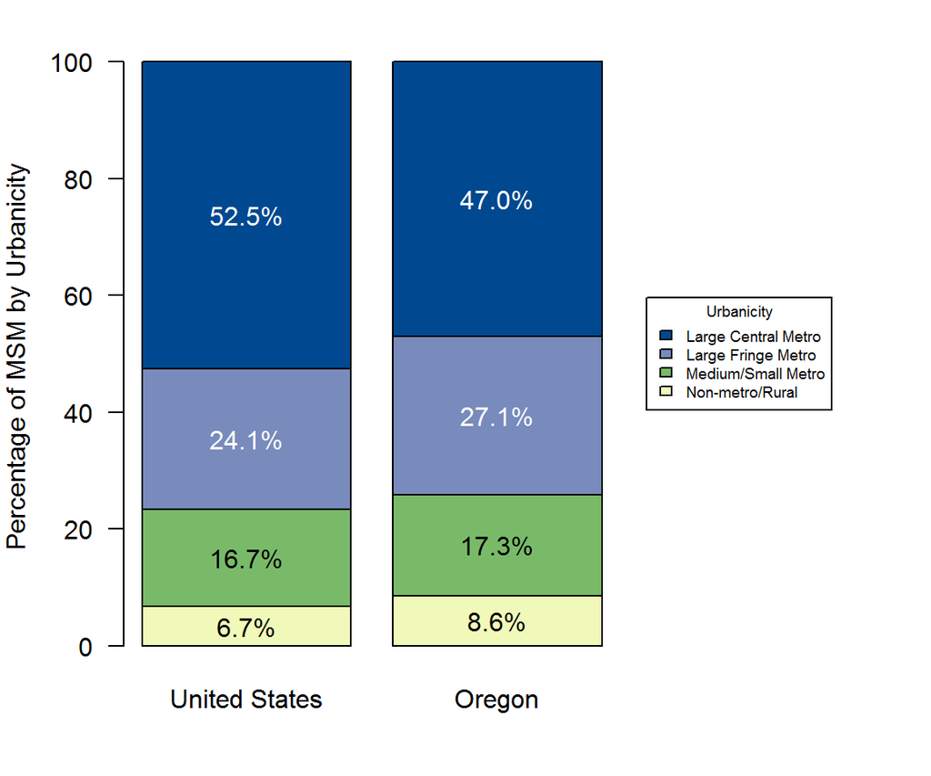

### MSM in Oregon Counties

Among counties or county-equivalent areas in Oregon, Multnomah County had the largest population of MSM at 28,949, representing 47.0% of all MSM in the state. Multnomah County also had the highest percentage of MSM among adult men in Oregon at 9.9%. This was greater than the percentage for Oregon as a whole, which was 4.2% of adult men.

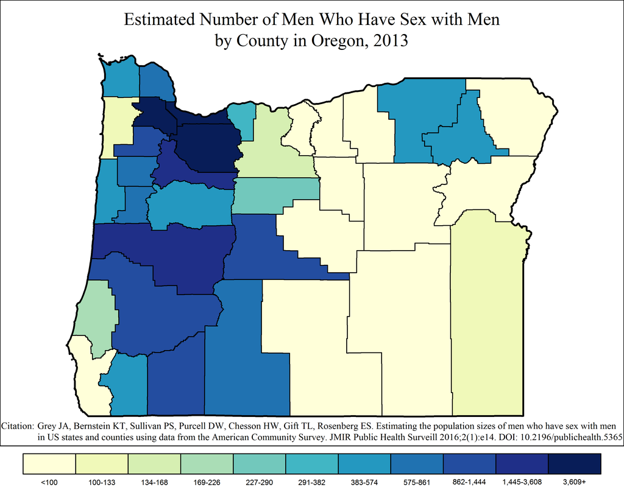

Note: Range cutpoints for the map are based on the distribution of MSM among all counties in the United States.

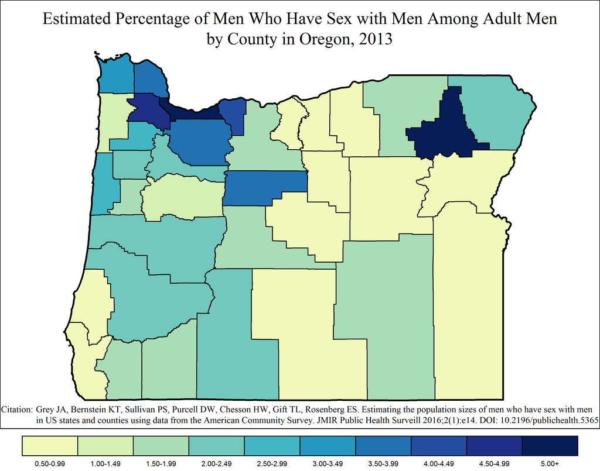

### MSM in Oregon Metropolitan Statistical Areas

#### Portland-Vancouver-Hillsboro Metropolitan Statistical Area

The Portland-Vancouver-Hillsboro MSA overlaps two states: Oregon and Washington. The Oregon portion of the MSA had the largest metropolitan population of MSM in Oregon at 45,653, or 74.1% of all MSM in the state and 86.2% of the 52,966 MSM in the MSA. Of the 686,408 adult men in the Oregon part of Portland-Vancouver-Hillsboro, an estimated 6.7% were MSM. This was greater than the percentage of MSM among adult men in the MSA as a whole, which was 6.3% of adult men (52,966 out of 846,640).

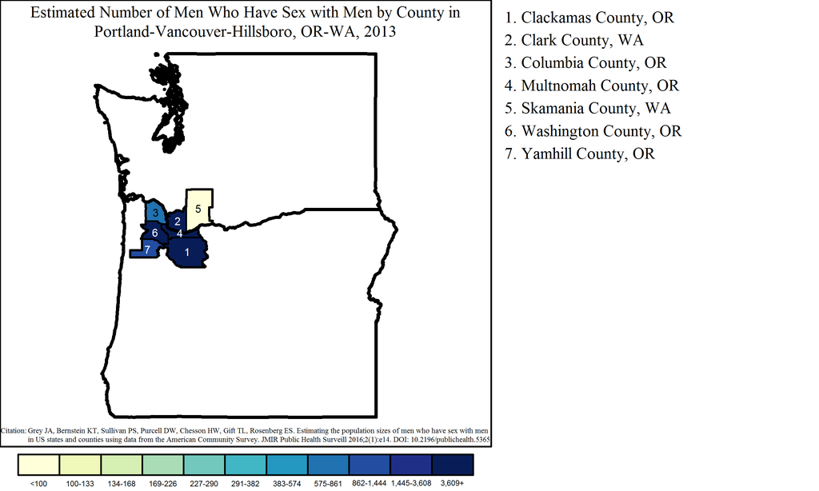

Note: Range cutpoints for the map are based on the distribution of MSM among all counties in the United States.

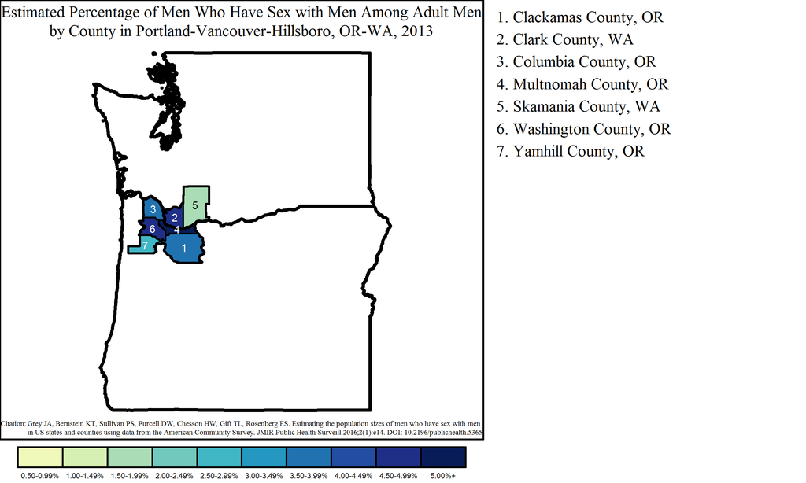

#### Eugene Metropolitan Statistical Area

The Eugene MSA had a population of 3,445 MSM, or 5.6% of all MSM in Oregon. Of the 138,300 adult men in Eugene, an estimated 2.5% were MSM.

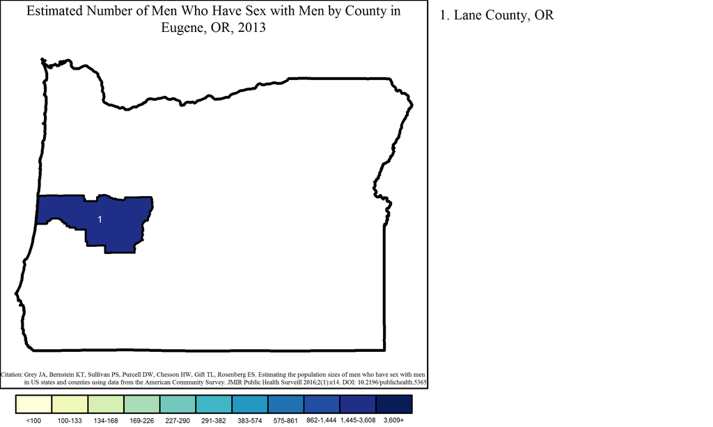

Note: Range cutpoints for the map are based on the distribution of MSM among all counties in the United States.

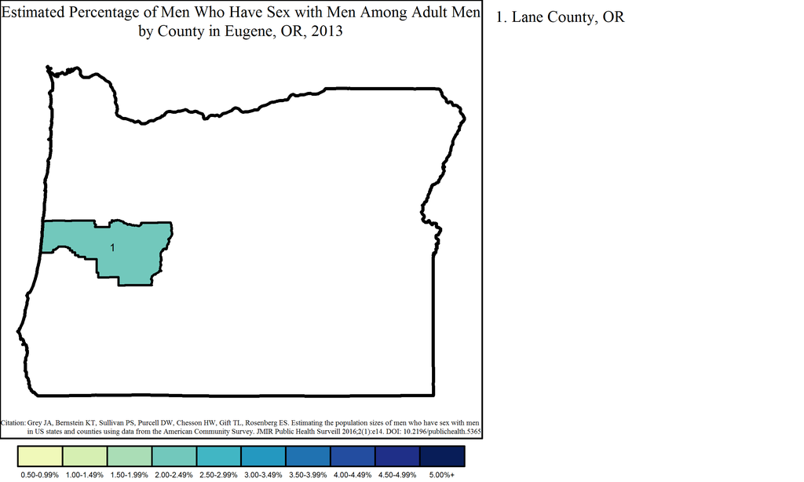

#### Salem Metropolitan Statistical Area

The Salem MSA had a population of 3,151 MSM, or 5.1% of all MSM in Oregon. Of the 143,573 adult men in Salem, an estimated 2.2% were MSM.

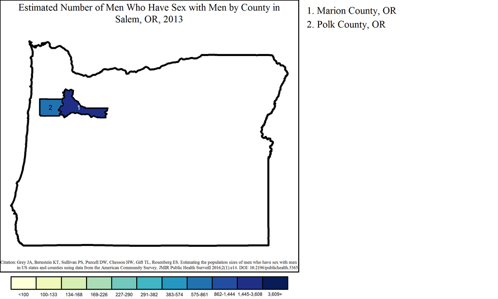

Note: Range cutpoints for the map are based on the distribution of MSM among all counties in the United States.

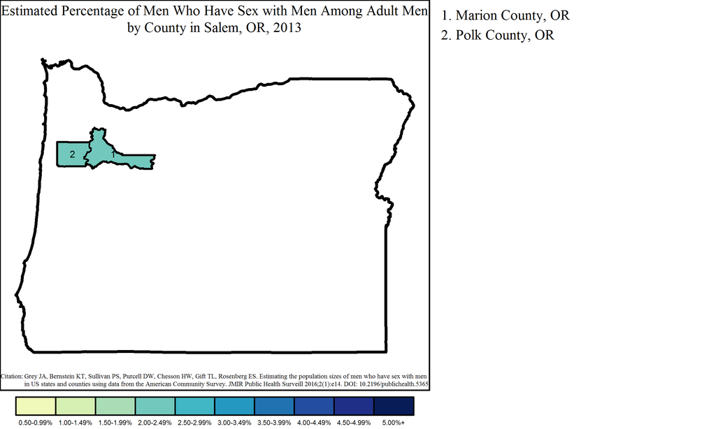

#### Medford Metropolitan Statistical Area

The Medford MSA had a population of 1,180 MSM, or 1.9% of all MSM in Oregon. Of the 77,529 adult men in Medford, an estimated 1.5% were MSM.

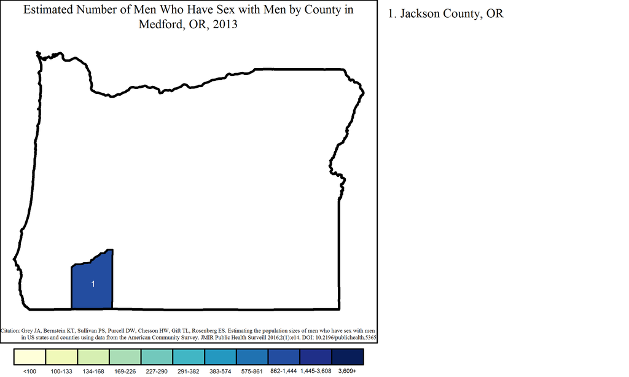

Note: Range cutpoints for the map are based on the distribution of MSM among all counties in the United States.

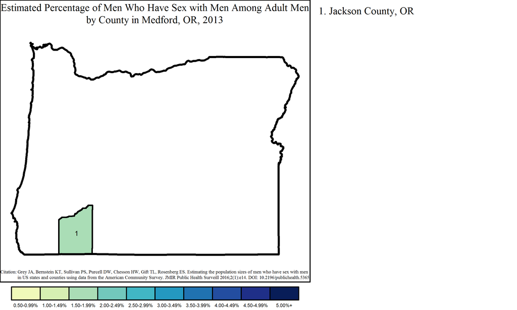

#### Bend-Redmond Metropolitan Statistical Area

The Bend-Redmond MSA had a population of 1,147 MSM, or 1.9% of all MSM in Oregon. Of the 60,735 adult men in Bend-Redmond, an estimated 1.9% were MSM.

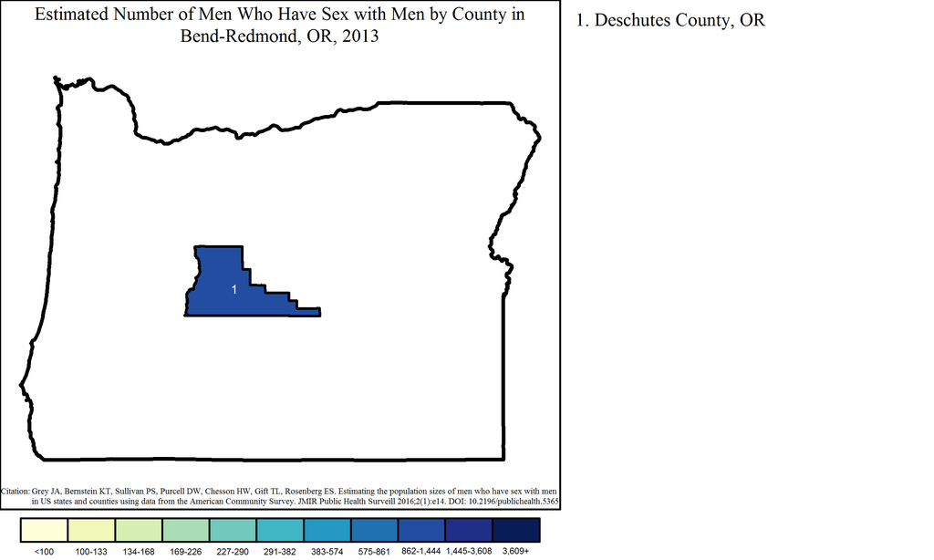

Note: Range cutpoints for the map are based on the distribution of MSM among all counties in the United States.

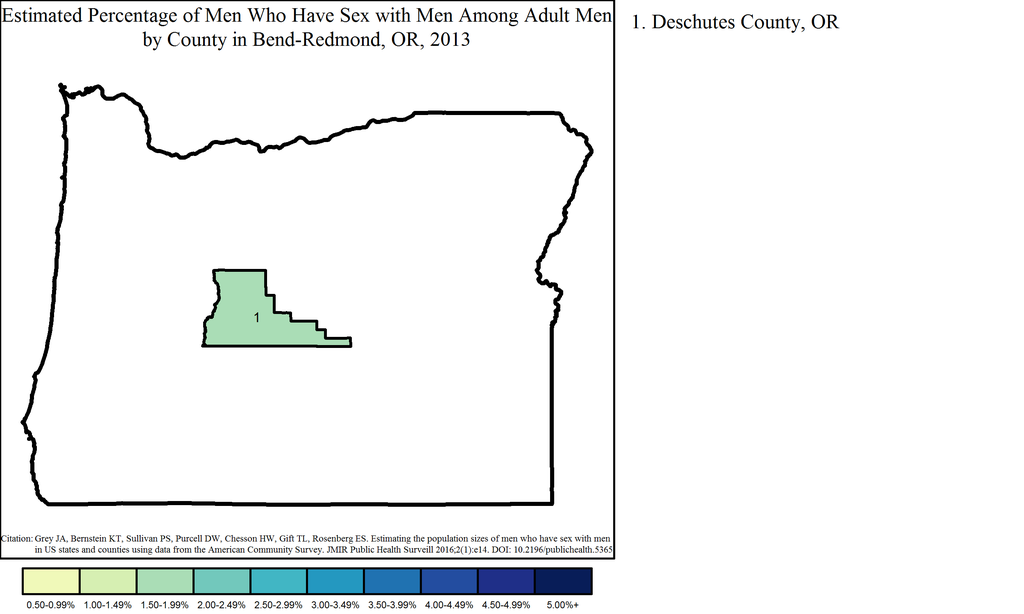

#### Corvallis Metropolitan Statistical Area

The Corvallis MSA had a population of 695 MSM, or 1.1% of all MSM in Oregon. Of the 35,522 adult men in Corvallis, an estimated 2.0% were MSM.

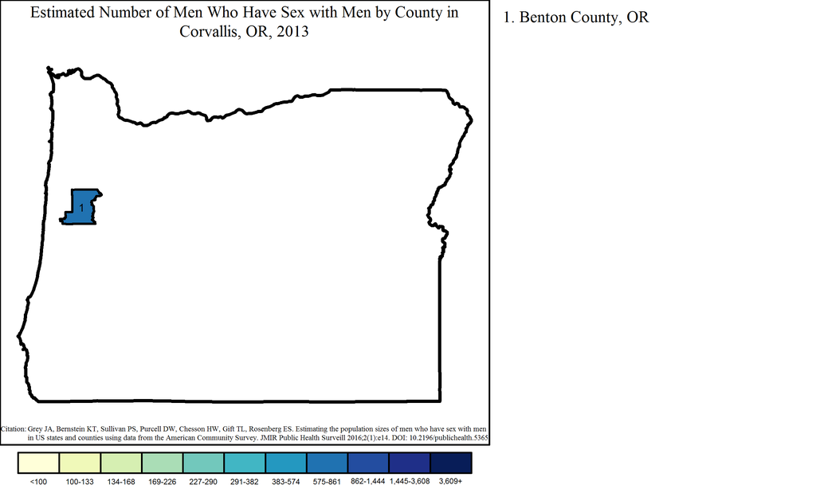

Note: Range cutpoints for the map are based on the distribution of MSM among all counties in the United States.

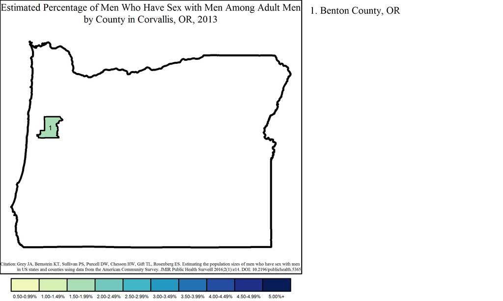

#### Albany Metropolitan Statistical Area

The Albany MSA had a population of 539 MSM, or 0.9% of all MSM in Oregon. Of the 43,631 adult men in Albany, an estimated 1.2% were MSM.

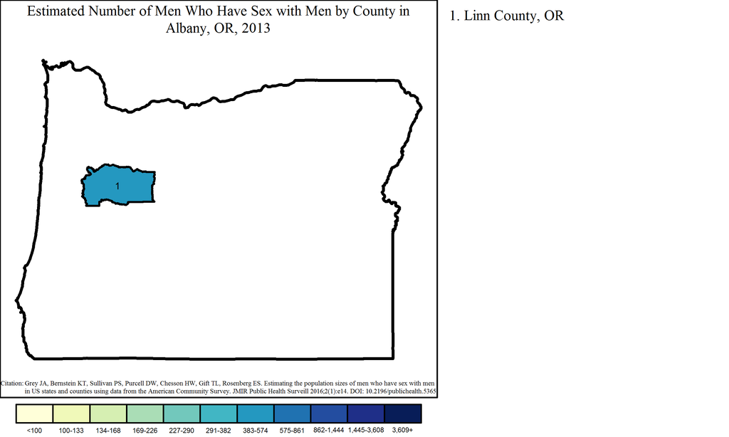

Note: Range cutpoints for the map are based on the distribution of MSM among all counties in the United States.

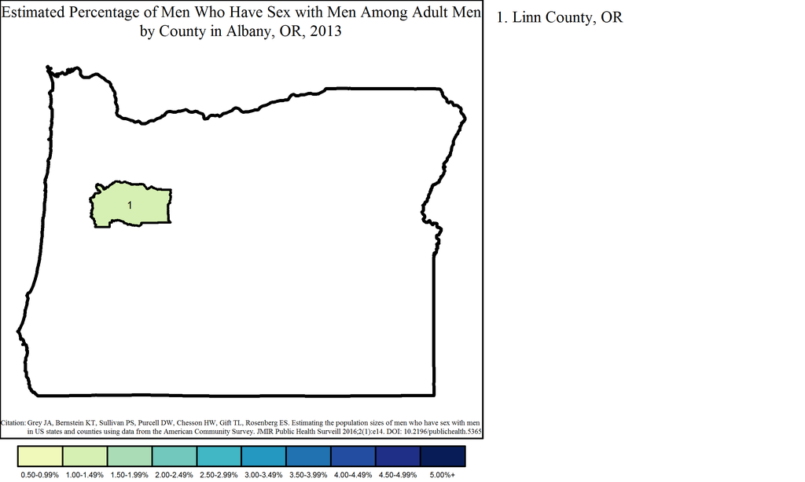

#### Grants Pass Metropolitan Statistical Area

The Grants Pass MSA had a population of 501 MSM, or 0.8% of all MSM in Oregon. Of the 31,706 adult men in Grants Pass, an estimated 1.6% were MSM.

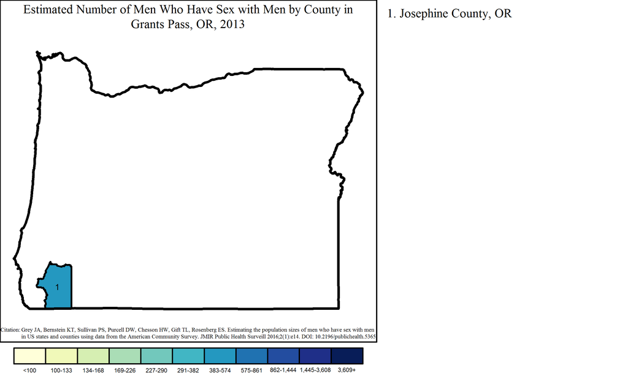

Note: Range cutpoints for the map are based on the distribution of MSM among all counties in the United States.

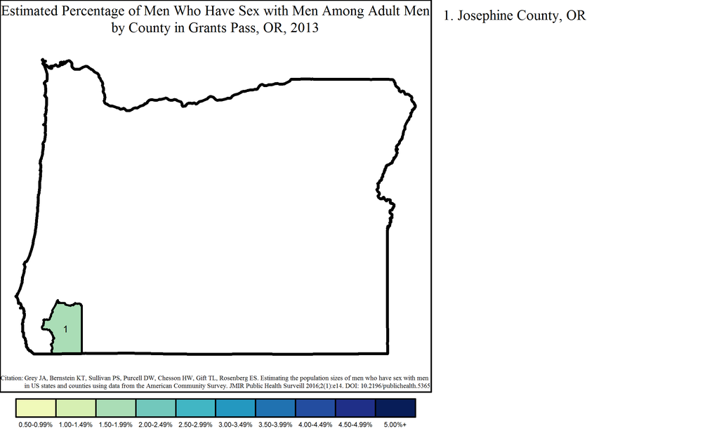